title: “PML Project” author: “Angelo Antonio Zuffianò” date: “24 Apr 2015” output: html_document: pandoc_args: [ “+RTS”, “-K64m”, “-RTS” ] —

### Introduction

The aim of the project was to use inertial sensor data to classify the correctness of a dumbbell lifts activity performed by an eterogeneous group of partecipants.

The provided data were organized into two datasets, **pml-training** and **pml-testing** respectively consisting of 19622 and 20 observations with 159 available predictors and 1 outcome variable named **classe**, only present in the training dataset and consisting of 5 different classes: A (correct execution), B-E (four different execution mistakes). The **pml-training** was chosen as the dataset on which designing, building and testing the prediction model, the **pml-testing** instead was reserved as smoking test dataset and used only for the course prediction assignment. For more information please refer to http://groupware.les.inf.puc-rio.br/har.

The **caret** package was used to generate the training and testing datasets, to fit the model and to predict outcomes starting from new data. To guarantee the results reproducibility a seed was set for random number generation.

```r
library(caret)
set.seed(7)
```

### Load, Clean and Split the Pie

Due to the presence of *“#DIV/0!”* errors in the **pml-training** dataset and to avoid possible issues in the data pre-processing and model training, the dataset was loaded replacing the *“#DIV/0!”* strings with the more traceable *“NA”* values.

```r
fullData = read.csv(fullDataPath, na.strings=c("NA", "#DIV/0!"));
```

Considered as **medium size**, the loaded dataset was then splitted over the outcome varible into two parts, a **training** (sub-)dataset representing the **60%** of the original set and a **testing** (sub-)dataset containg the remaining **40%** of the data. The stratified random splitting was performed using the default behaviour of the data partitioning function available in the caret package.

```r
inDataSet <- createDataPartition(fullData$classe, p = .60, list = FALSE)
trainingSet <- fullData[inDataSet,]
testingSet <- fullData[-inDataSet,]
```

### The Good, the Bad and the Ugly: Predictors Selection

In order to reduce the number of predictors to a smaller but meaningfull (read no information loss or information compression) group to be used during the model fitting, all the features having *“NA”* values were removed from both the training and the testing datasets.

```r
filtTrainingSet <- trainingSet[,colSums(is.na(trainingSet)) == 0]
filtTestingSet <- testingSet[,colSums(is.na(testingSet)) == 0]
```

Continuing with the predictors pruning, a set of features, strictly related to the way the data acquisition sessions were conducted by the research team, were also removed from the filtered datasets. This group of predictors included for instance timestamps, user name or acquisition windows information.

```r
filtTrainingSet <- subset(filtTrainingSet, select=-c(X, raw_timestamp_part_1, raw_timestamp_part_2, cvtd_timestamp, new_window, num_window, user_name))

filtTestingSet <- subset(filtTestingSet, select=-c(X, raw_timestamp_part_1, raw_timestamp_part_2, cvtd_timestamp, new_window, num_window, user_name))
```

The last step of features filtering was the analysis of the **multicollinearity** among the remaining set of predictors, in other words, how much correlated were the features. The correlation between the predictors in the training set (except for the outcome variable) was computed and all the precitors with a correlation higher than **0.90** were removed, this because those high correlated features did not add any additional useful information to the dataset.

```r
corrMat <- cor(filtTrainingSet[, !(colnames(filtTrainingSet) == "classe")])
highCorr <- findCorrelation(corrMat, 0.90)

filtTrainingSet <- filtTrainingSet[,-highCorr]
filtTestingSet <- filtTestingSet[,-highCorr]
```

At the end of the predictors selection process, only 45 features were selected as candidates for the training. The figure below depicts the computed correlation matrix after the predictors pruning for the training set.

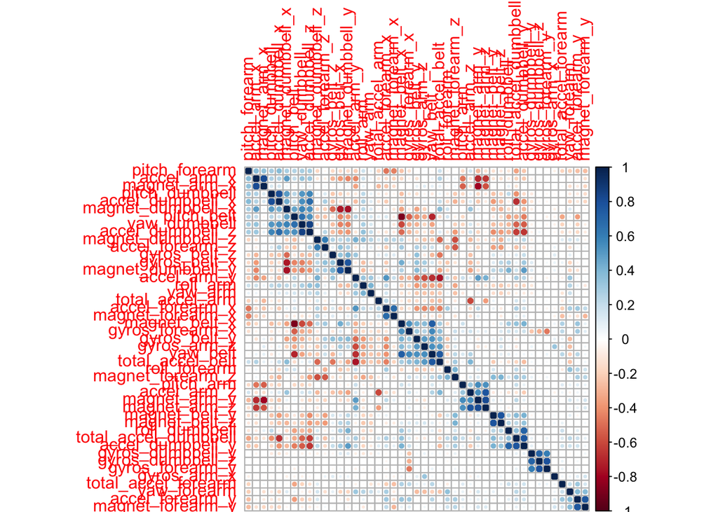

As a final pre-processing step, the filtered datasets were then **standardized** using the *“center”* and *“scale”* methods available in the pre-process caret function. The outcomes columns, previously excluded from the standardization, were then added again to the datasets.

```r
preProc <- preProcess(filtTrainingSet[, !(colnames(filtTrainingSet) == "classe")],
                      method = c("center", "scale"))

preProcTraining <- predict(preProc, filtTrainingSet[, !(colnames(filtTrainingSet) == "classe")])
preProcTesting <- predict(preProc, filtTestingSet[, !(colnames(filtTestingSet) == "classe")])

preProcTraining$classe <- filtTrainingSet$classe
preProcTesting$classe <- filtTestingSet$classe
```

### I found myself deep in a Random Forest

Due to its good tradeoff of accuracy/tuning-complexity the **random forest** was chosen as classification model. To reduce the risk of **overfitting** the *repeated K–fold cross–validation* was chosen as resapmling method in the training control function considering *10 folds* and *10 repetitions* (experimental values).

```r
train_control <- trainControl(method="repeatedcv", number=10, repeats=10, allowParallel=TRUE)
```

The model was then fit using all the available predictors (except for the outcome), the *OOB* (Out-Of-Bag) as error estimate, **Accuracy** as metric, the default number of trees *500* and enabling the proximity matrix.

```r
modFit <- train(preProcTraining$classe~., data=preProcTraining, method="rf", trControl=train_control, ntree=500, prox=TRUE)
```

```r
print(modFit)
```

```
## Random Forest
##
## 11776 samples
##    45 predictor
##     5 classes: 'A', 'B', 'C', 'D', 'E'
##
## No pre-processing
## Resampling: Cross-Validated (10 fold, repeated 10 times)
##
## Summary of sample sizes: 10597, 10599, 10599, 10599, 10598, 10599, ...
##
## Resampling results across tuning parameters:
##
##   mtry  Accuracy   Kappa      Accuracy SD  Kappa SD
##    2    0.9886037  0.9855823  0.003273147  0.004142372
##   23    0.9902512  0.9876677  0.003016371  0.003816687
##   45    0.9822859  0.9775906  0.004161928  0.005266548
##
## Accuracy was used to select the optimal model using  the largest value.
## The final value used for the model was mtry = 23.
```

As shown by the model summary, the highest accuracy (**99%**) was reached with a number of randomly sampled variables (at each split) of 23, this is also depicted by the figure below.

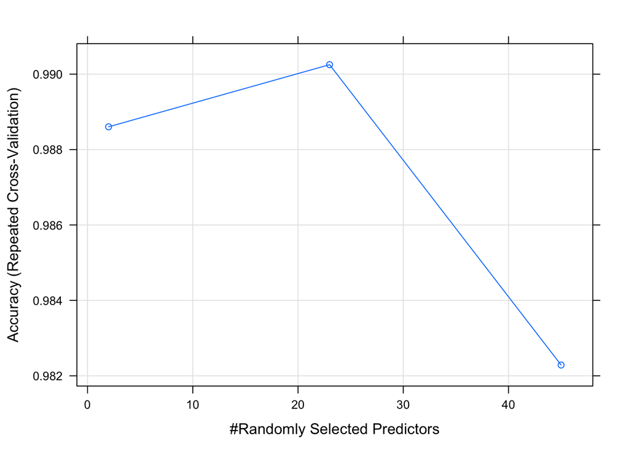

The confusion matrix of the final model shows the obtained classification error for each predicted class, with maximum value representing the **in-sample error**.

```r
print(modFit$finalModel$confusion)
```

```
##      A    B    C    D    E class.error
## A 3342    3    1    0    2 0.001792115
## B   18 2248   12    1    0 0.013602457
## C    0   18 2027    9    0 0.013145083
## D    0    0   23 1905    2 0.012953368
## E    0    0    5    7 2153 0.005542725
```